# Project: Investigate a Dataset - [tmdb_movies dataset]

- Introduction
- Data Wrangling
- Exploratory Data Analysis
- Conclusions

# Introduction

## Dataset Description

> This data set contains information about 10,000 movies collected from The Movie Database (TMDb), The Movie Database (TMDb) is a community built movie and TV database, We love how they support their community and the passion with which they have built

### Columns of tmdb_movies dataset:

- id:a unique identifier for each movie.
- imdb_id: a unique identifier for IMDB of movie
- popularity: A numeric quantity specifying the movie popularity.
- budget: The budget in which the movie was made.
- revenue: The worldwide revenue generated by the movie.
- original_title: The title of the movie before adaptation.
- cast: The name of lead and supporting actors.
- homepage: A link to the homepage of the movie.
- director: the director of the movie
- tagline: Movie's tagline.
- keywords: The keywords or tags related to the movie.
- overview: A brief description of the movie.
- runtime: The running time of the movie.
- genres: The genre of the movie, Action, Comedy ,Thriller etc.
- production_companies: The production house of the movie.
- release_date: The date on which it was released.
- vote_count: count ratings te movie recieved
- vote_average: average ratings the movie recieved.
- release_year: the year which the movie released in
- budget_adj: shows the budget associated movie
- revenue_adj: shows the revenue associated movie

### Question(s) for Analysis

- what is the highest rated movie over all years?
- what is the top eight popular movies?
- which director have produced the best movies in 2010?
- what is the average vote_count for movies?
- which movie have the highest runtime?
- what is the relationship between revenue and popularity
- what is the relationship between revenue and budget
- what is the relationship between budget and popularity
- Which Movie Has The Highest profit?
- Movies with most and least earned revenue

```python
#we import our libraries that we will use
import numpy as np
import pandas as pd
import matplotlib.pyplot as plt
import seaborn as sns
sns.set(style="darkgrid")
# we use theme darkgrid for better visualization
```

# Data Wrangling

> here we view our data and identify any problem in structure of data

## General Properties

- Assessing and build intuition
- Defining shape and data types
- Display the summary of data including nan-values
- take observation about what to need to be changed or removed then try to solve it

### we will start load our data and print first five lines

```python
#reading our data
data=pd.read_csv('tmdb-movies.csv')
data.head() #view our data
```

|  | id | imdb_id | popularity | budget | revenue | original_title | cast | homepage | director | tagline | ... | overview | runtime | genres | production_companies | release_date | vote_count | vote_average | release_year | budget_adj | revenue_adj |
| --- | --- | --- | --- | --- | --- | --- | --- | --- | --- | --- | --- | --- | --- | --- | --- | --- | --- | --- | --- | --- | --- |
| 0 | 135397 | tt0369610 | 32.985763 | 150000000 | 1513528810 | Jurassic World | Chris Pratt\|Bryce Dallas Howard\|Irrfan Khan\|Vi... | http://www.jurassicworld.com/ | Colin Trevorrow | The park is open. | ... | Twenty-two years after the events of Jurassic ... | 124 | Action\|Adventure\|Science Fiction\|Thriller | Universal Studios\|Amblin Entertainment\|Legenda... | 6/9/15 | 5562 | 6.5 | 2015 | 1.379999e+08 | 1.392446e+09 |
| 1 | 76341 | tt1392190 | 28.419936 | 150000000 | 378436354 | Mad Max: Fury Road | Tom Hardy\|Charlize Theron\|Hugh Keays-Byrne\|Nic... | http://www.madmaxmovie.com/ | George Miller | What a Lovely Day. | ... | An apocalyptic story set in the furthest reach... | 120 | Action\|Adventure\|Science Fiction\|Thriller | Village Roadshow Pictures\|Kennedy Miller Produ... | 5/13/15 | 6185 | 7.1 | 2015 | 1.379999e+08 | 3.481613e+08 |
| 2 | 262500 | tt2908446 | 13.112507 | 110000000 | 295238201 | Insurgent | Shailene Woodley\|Theo James\|Kate Winslet\|Ansel... | http://www.thedivergentseries.movie/#insurgent | Robert Schwentke | One Choice Can Destroy You | ... | Beatrice Prior must confront her inner demons ... | 119 | Adventure\|Science Fiction\|Thriller | Summit Entertainment\|Mandeville Films\|Red Wago... | 3/18/15 | 2480 | 6.3 | 2015 | 1.012000e+08 | 2.716190e+08 |
| 3 | 140607 | tt2488496 | 11.173104 | 200000000 | 2068178225 | Star Wars: The Force Awakens | Harrison Ford\|Mark Hamill\|Carrie Fisher\|Adam D... | http://www.starwars.com/films/star-wars-episod... | J.J. Abrams | Every generation has a story. | ... | Thirty years after defeating the Galactic Empi... | 136 | Action\|Adventure\|Science Fiction\|Fantasy | Lucasfilm\|Truenorth Productions\|Bad Robot | 12/15/15 | 5292 | 7.5 | 2015 | 1.839999e+08 | 1.902723e+09 |
| 4 | 168259 | tt2820852 | 9.335014 | 190000000 | 1506249360 | Furious 7 | Vin Diesel\|Paul Walker\|Jason Statham\|Michelle ... | http://www.furious7.com/ | James Wan | Vengeance Hits Home | ... | Deckard Shaw seeks revenge against Dominic Tor... | 137 | Action\|Crime\|Thriller | Universal Pictures\|Original Film\|Media Rights ... | 4/1/15 | 2947 | 7.3 | 2015 | 1.747999e+08 | 1.385749e+09 |

5 rows × 21 columns

### we conclude from data set:

- imdb_id column is string column contain letters and numbers
- budget and revenue are of type int
- home page have a lot of null values
- genres contain '|' between its data

```python
# we will look at the dismension of our data set
data.shape
```

```
(10866, 21)
```

> its look very large as there is 21 columns and 10866 rows

```python
data.index # number of our dataset rows
```

```
RangeIndex(start=0, stop=10866, step=1)
```

> rows start from 0 to 10866

## descriptive statistics

> we will describe our data to see count,max,min,mean,standard deviation,1st quartile,2nd quartile and 3rd quartile of columns

```python
data.describe()
```

|  | id | popularity | budget | revenue | runtime | vote_count | vote_average | release_year | budget_adj | revenue_adj |
| --- | --- | --- | --- | --- | --- | --- | --- | --- | --- | --- |
| count | 10866.000000 | 10866.000000 | 1.086600e+04 | 1.086600e+04 | 10866.000000 | 10866.000000 | 10866.000000 | 10866.000000 | 1.086600e+04 | 1.086600e+04 |
| mean | 66064.177434 | 0.646441 | 1.462570e+07 | 3.982332e+07 | 102.070863 | 217.389748 | 5.974922 | 2001.322658 | 1.755104e+07 | 5.136436e+07 |
| std | 92130.136561 | 1.000185 | 3.091321e+07 | 1.170035e+08 | 31.381405 | 575.619058 | 0.935142 | 12.812941 | 3.430616e+07 | 1.446325e+08 |
| min | 5.000000 | 0.000065 | 0.000000e+00 | 0.000000e+00 | 0.000000 | 10.000000 | 1.500000 | 1960.000000 | 0.000000e+00 | 0.000000e+00 |
| 25% | 10596.250000 | 0.207583 | 0.000000e+00 | 0.000000e+00 | 90.000000 | 17.000000 | 5.400000 | 1995.000000 | 0.000000e+00 | 0.000000e+00 |
| 50% | 20669.000000 | 0.383856 | 0.000000e+00 | 0.000000e+00 | 99.000000 | 38.000000 | 6.000000 | 2006.000000 | 0.000000e+00 | 0.000000e+00 |
| 75% | 75610.000000 | 0.713817 | 1.500000e+07 | 2.400000e+07 | 111.000000 | 145.750000 | 6.600000 | 2011.000000 | 2.085325e+07 | 3.369710e+07 |
| max | 417859.000000 | 32.985763 | 4.250000e+08 | 2.781506e+09 | 900.000000 | 9767.000000 | 9.200000 | 2015.000000 | 4.250000e+08 | 2.827124e+09 |

### we observe

- runtime has 0 at min
- budjet, revenue ,budget_adj and revenue_adj have 0.000000e+00 at min, 25% and 50%

## we have alot of null values that need to be cleaned

```python
data.info() #checking our data
```

```
<class 'pandas.core.frame.DataFrame'>
RangeIndex: 10866 entries, 0 to 10865
Data columns (total 21 columns):
 #   Column                Non-Null Count  Dtype
---  ------                --------------  -----
 0   id                    10866 non-null  int64
 1   imdb_id               10856 non-null  object
 2   popularity            10866 non-null  float64
 3   budget                10866 non-null  int64
 4   revenue               10866 non-null  int64
 5   original_title        10866 non-null  object
 6   cast                  10790 non-null  object
 7   homepage              2936 non-null   object
 8   director              10822 non-null  object
 9   tagline               8042 non-null   object
 10  keywords              9373 non-null   object
 11  overview              10862 non-null  object
 12  runtime               10866 non-null  int64
 13  genres                10843 non-null  object
 14  production_companies  9836 non-null   object
 15  release_date          10866 non-null  object
 16  vote_count            10866 non-null  int64
 17  vote_average          10866 non-null  float64
 18  release_year          10866 non-null  int64
 19  budget_adj            10866 non-null  float64
 20  revenue_adj           10866 non-null  float64
dtypes: float64(4), int64(6), object(11)
memory usage: 1.7+ MB
```

### we see:

- imdb_id has 10856 data from 10866
- cast has 10790 data from 10866
- homepage has 2936 data from 10866
- director has 10822 data from 10866
- tagline has 8042 data from 10866
- keywords has 9373 data from 10866
- overview has 10862 data from 10866
- genres has 10843 data from 10866
- production_companies has 9836 data from 10866

```python
data.isnull().sum() #viewing how many null values in our data
```

```
id                         0
imdb_id                   10
popularity                 0
budget                     0
revenue                    0
original_title             0
cast                      76
homepage                7930
director                  44
tagline                 2824
keywords                1493
overview                   4
runtime                    0
genres                    23
production_companies    1030
release_date               0
vote_count                 0
vote_average               0
release_year               0
budget_adj                 0
revenue_adj                0
dtype: int64
```

- imdb_id column have 10 null
- cast column have 76 null
- homepage have 7930 null
- director have 44 null
- tagline have 2824 null
- keywords have 1493 null
- overview have 4 null
- genres have 23 null production_companies have 1030 null ### we need to drop all those null

## checking duplicate

```python
sum(data.duplicated()) #printing the sum of duplicate rows
```

```
1
```

```python
data[data.duplicated()] #showing duplicate
```

|  | id | imdb_id | popularity | budget | revenue | original_title | cast | homepage | director | tagline | ... | overview | runtime | genres | production_companies | release_date | vote_count | vote_average | release_year | budget_adj | revenue_adj |
| --- | --- | --- | --- | --- | --- | --- | --- | --- | --- | --- | --- | --- | --- | --- | --- | --- | --- | --- | --- | --- | --- |
| 2090 | 42194 | tt0411951 | 0.59643 | 30000000 | 967000 | TEKKEN | Jon Foo\|Kelly Overton\|Cary-Hiroyuki Tagawa\|Ian... | NaN | Dwight H. Little | Survival is no game | ... | In the year of 2039, after World Wars destroy ... | 92 | Crime\|Drama\|Action\|Thriller\|Science Fiction | Namco\|Light Song Films | 3/20/10 | 110 | 5.0 | 2010 | 30000000.0 | 967000.0 |

1 rows × 21 columns

> we have one duplicate row at index 2090

### it seems we have alot of zero at column revenue,budget and runtime we need to clean them

```python
data[data['revenue']==0]['revenue'].count() #viewing number of zero in revenue column
```

```
6016
```

```python
data[data['budget']==0]['budget'].count() #viewing number of zero in budget column
```

```
5696
```

```python
data[data['runtime']==0]['runtime'].count() #viewing number of zero in runtime column
```

```
31
```

- we have 6016 zero at revenue column
- we have 5696 zero at budget column
- we have 31 zero at runtime column

## we discovered that:

- we have 21 columns and 10866 rows
- we have columns that have a lot of null values like homepage ,tagline ,keywords ,production_campanies so we will drop them
- we will drop unused columns like imdb_id ,cast ,overview ,budget_adj ,revenue_adj
- we have 1 duplicated row which with index 2090
- we have 6016 zero values at revenue column
- we have 5696 zero values at budget column
- we have 31 zero values at runtime column

# Data Cleaning

## we will start to drop unnecessary columns

```python
data.drop(['imdb_id','cast', 'homepage', 'tagline', 'keywords','overview','production_companies','budget_adj','revenue_adj'], axis = 1, inplace = True)
data.head() #dropping columns then show data
```

|  | id | popularity | budget | revenue | original_title | director | runtime | genres | release_date | vote_count | vote_average | release_year |
| --- | --- | --- | --- | --- | --- | --- | --- | --- | --- | --- | --- | --- |
| 0 | 135397 | 32.985763 | 150000000 | 1513528810 | Jurassic World | Colin Trevorrow | 124 | Action\|Adventure\|Science Fiction\|Thriller | 6/9/15 | 5562 | 6.5 | 2015 |
| 1 | 76341 | 28.419936 | 150000000 | 378436354 | Mad Max: Fury Road | George Miller | 120 | Action\|Adventure\|Science Fiction\|Thriller | 5/13/15 | 6185 | 7.1 | 2015 |
| 2 | 262500 | 13.112507 | 110000000 | 295238201 | Insurgent | Robert Schwentke | 119 | Adventure\|Science Fiction\|Thriller | 3/18/15 | 2480 | 6.3 | 2015 |
| 3 | 140607 | 11.173104 | 200000000 | 2068178225 | Star Wars: The Force Awakens | J.J. Abrams | 136 | Action\|Adventure\|Science Fiction\|Fantasy | 12/15/15 | 5292 | 7.5 | 2015 |
| 4 | 168259 | 9.335014 | 190000000 | 1506249360 | Furious 7 | James Wan | 137 | Action\|Crime\|Thriller | 4/1/15 | 2947 | 7.3 | 2015 |

## we have 44 missing values at director and 23 at genres columns we need to drop them

```python
data.info() #checking the data
```

```
<class 'pandas.core.frame.DataFrame'>
RangeIndex: 10866 entries, 0 to 10865
Data columns (total 12 columns):
 #   Column          Non-Null Count  Dtype
---  ------          --------------  -----
 0   id              10866 non-null  int64
 1   popularity      10866 non-null  float64
 2   budget          10866 non-null  int64
 3   revenue         10866 non-null  int64
 4   original_title  10866 non-null  object
 5   director        10822 non-null  object
 6   runtime         10866 non-null  int64
 7   genres          10843 non-null  object
 8   release_date    10866 non-null  object
 9   vote_count      10866 non-null  int64
 10  vote_average    10866 non-null  float64
 11  release_year    10866 non-null  int64
dtypes: float64(2), int64(6), object(4)
memory usage: 1018.8+ KB
```

> there is alot of null values

```python
data.isnull().sum() #viewing how many null values in our data
```

```
id                 0
popularity         0
budget             0
revenue            0
original_title     0
director          44
runtime            0
genres            23
release_date       0
vote_count         0
vote_average       0
release_year       0
dtype: int64
```

- we have 44 null values at director column and 23 null values at genres column we need to drop them

```python
data.dropna(inplace=True) #dropping missing values
```

> we dropped missing values at director and genres

## good we don't have null values anymore

```python
data.info()
```

```
<class 'pandas.core.frame.DataFrame'>
Int64Index: 10801 entries, 0 to 10865
Data columns (total 12 columns):
 #   Column          Non-Null Count  Dtype
---  ------          --------------  -----
 0   id              10801 non-null  int64
 1   popularity      10801 non-null  float64
 2   budget          10801 non-null  int64
 3   revenue         10801 non-null  int64
 4   original_title  10801 non-null  object
 5   director        10801 non-null  object
 6   runtime         10801 non-null  int64
 7   genres          10801 non-null  object
 8   release_date    10801 non-null  object
 9   vote_count      10801 non-null  int64
 10  vote_average    10801 non-null  float64
 11  release_year    10801 non-null  int64
dtypes: float64(2), int64(6), object(4)
memory usage: 1.1+ MB
```

> all columns have 10801 out of 10801 so there is no null data

## lets drop duplicates too

```python
sum(data.duplicated()) #showing number of duplicates
```

```
1
```

> there is one duplicate row

```python
data.drop_duplicates(inplace=True) #dropping duplicates
```

> we dropped the duplicate row

```python
sum(data.duplicated()) # there is no duplicates anymore
```

```
0
```

> there is no duplicate anymore

## now we will focus on getting ride of zero at columns too

```python
data[data['revenue']==0]['revenue'].count()
```

```
5952
```

```python
data[data['budget']==0]['budget'].count()
```

```
5636
```

```python
data[data['runtime']==0]['runtime'].count()
```

```
28
```

## we will replace zero with NaN at budget,revenue,runtime columns

```python
data['budget'] = data['budget'].replace(0, np.NaN)
data['revenue'] = data['revenue'].replace(0, np.NaN)
data['runtime'] =data['runtime'].replace(0, np.NaN)
```

> we replaced 0 in budget, revenue , runtime columns with NaN

## there is no zero at budget,revenue,runtime columns anymore lets check them

```python
data[data['revenue']==0]['revenue'].count()
```

```
0
```

```python
data[data['budget']==0]['budget'].count()
```

```
0
```

```python
data[data['runtime']==0]['runtime'].count()
```

```
0
```

> we don't have zero any more

```python
data.info()
```

```
<class 'pandas.core.frame.DataFrame'>
Int64Index: 10800 entries, 0 to 10865
Data columns (total 12 columns):
 #   Column          Non-Null Count  Dtype
---  ------          --------------  -----
 0   id              10800 non-null  int64
 1   popularity      10800 non-null  float64
 2   budget          5164 non-null   float64
 3   revenue         4848 non-null   float64
 4   original_title  10800 non-null  object
 5   director        10800 non-null  object
 6   runtime         10772 non-null  float64
 7   genres          10800 non-null  object
 8   release_date    10800 non-null  object
 9   vote_count      10800 non-null  int64
 10  vote_average    10800 non-null  float64
 11  release_year    10800 non-null  int64
dtypes: float64(5), int64(3), object(4)
memory usage: 1.1+ MB
```

> we have missing data in budget, revenue and runtime

```python
data.fillna(data.mean(),inplace=True) #here we replace null values
```

> we replaced missing data in budget, revenue and runtime with mean

```python
data.info() #lets check data
```

```
<class 'pandas.core.frame.DataFrame'>
Int64Index: 10800 entries, 0 to 10865
Data columns (total 12 columns):
 #   Column          Non-Null Count  Dtype
---  ------          --------------  -----
 0   id              10800 non-null  int64
 1   popularity      10800 non-null  float64
 2   budget          10800 non-null  float64
 3   revenue         10800 non-null  float64
 4   original_title  10800 non-null  object
 5   director        10800 non-null  object
 6   runtime         10800 non-null  float64
 7   genres          10800 non-null  object
 8   release_date    10800 non-null  object
 9   vote_count      10800 non-null  int64
 10  vote_average    10800 non-null  float64
 11  release_year    10800 non-null  int64
dtypes: float64(5), int64(3), object(4)
memory usage: 1.1+ MB
```

## now our data is clean

> there is no null anymore

## checking the type of budget , revenue and runtime

```python
data['budget'].dtypes
```

```
dtype('float64')
```

```python
data['budget']
```

```
0        1.500000e+08
1        1.500000e+08
2        1.100000e+08
3        2.000000e+08
4        1.900000e+08
             ...
10861    3.076690e+07
10862    3.076690e+07
10863    3.076690e+07
10864    3.076690e+07
10865    1.900000e+04
Name: budget, Length: 10800, dtype: float64
```

> we notice that budget column change from int to float

```python
data['revenue'].dtypes
```

```
dtype('float64')
```

```python
data['revenue']
```

```
0        1.513529e+09
1        3.784364e+08
2        2.952382e+08
3        2.068178e+09
4        1.506249e+09
             ...
10861    8.925500e+07
10862    8.925500e+07
10863    8.925500e+07
10864    8.925500e+07
10865    8.925500e+07
Name: revenue, Length: 10800, dtype: float64
```

> we notice that revenue column change from int to float

```python
data['runtime'].dtypes
```

```
dtype('float64')
```

```python
data['runtime']
```

```
0        124.0
1        120.0
2        119.0
3        136.0
4        137.0
         ...
10861     95.0
10862    176.0
10863     94.0
10864     80.0
10865     74.0
Name: runtime, Length: 10800, dtype: float64
```

> we notice that runtime column change from int to float

```python
data['budget']=data['budget'].astype(int)
data['revenue']=data['revenue'].astype(int)
data['runtime']=data['runtime'].astype(int)
```

> changing them to int type

```python
data.info() #lets check data
```

```
<class 'pandas.core.frame.DataFrame'>
Int64Index: 10800 entries, 0 to 10865
Data columns (total 12 columns):
 #   Column          Non-Null Count  Dtype
---  ------          --------------  -----
 0   id              10800 non-null  int64
 1   popularity      10800 non-null  float64
 2   budget          10800 non-null  int32
 3   revenue         10800 non-null  int32
 4   original_title  10800 non-null  object
 5   director        10800 non-null  object
 6   runtime         10800 non-null  int32
 7   genres          10800 non-null  object
 8   release_date    10800 non-null  object
 9   vote_count      10800 non-null  int64
 10  vote_average    10800 non-null  float64
 11  release_year    10800 non-null  int64
dtypes: float64(2), int32(3), int64(3), object(4)
memory usage: 970.3+ KB
```

> they returned to int again

## Exploratory Data Analysis

### Question(s) for Analysis

- what is the highest rated movie over all years?
- what is the top eight popular movies?
- which director have produced the best movies in 2010?
- what is the average vote_count for movies?
- which movies have the highest runtime?
- what is the relation ship between revenue and popularity
- what is the relation ship between revenue and budget
- what is the relation ship between budget and popularity
- Which Movie Has The Highest profit?
- Movies with most and least earned revenue

## lets make some visualiztion to our data

### visualize with histogram for each feature with no of movies in dataset

```
array([[<AxesSubplot:title={'center':'id'}>,
        <AxesSubplot:title={'center':'popularity'}>,
        <AxesSubplot:title={'center':'budget'}>],
       [<AxesSubplot:title={'center':'revenue'}>,
        <AxesSubplot:title={'center':'runtime'}>,
        <AxesSubplot:title={'center':'vote_count'}>],
       [<AxesSubplot:title={'center':'vote_average'}>,
        <AxesSubplot:title={'center':'release_year'}>, <AxesSubplot:>]],
      dtype=object)
```

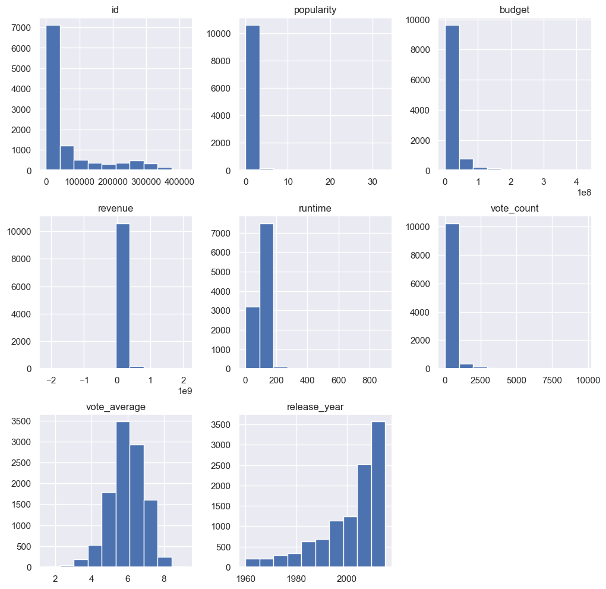

```python
data.hist(figsize=(12,12)) #here we visualize data with histograms
```

### we noticed:

- release year is left skewed, vote average is symmetric
- id, vote count, popularity and budget are right skewed

## visualize features with lineplot

```
array([<AxesSubplot:>, <AxesSubplot:>, <AxesSubplot:>, <AxesSubplot:>,
       <AxesSubplot:>, <AxesSubplot:>, <AxesSubplot:>, <AxesSubplot:>],
      dtype=object)
```

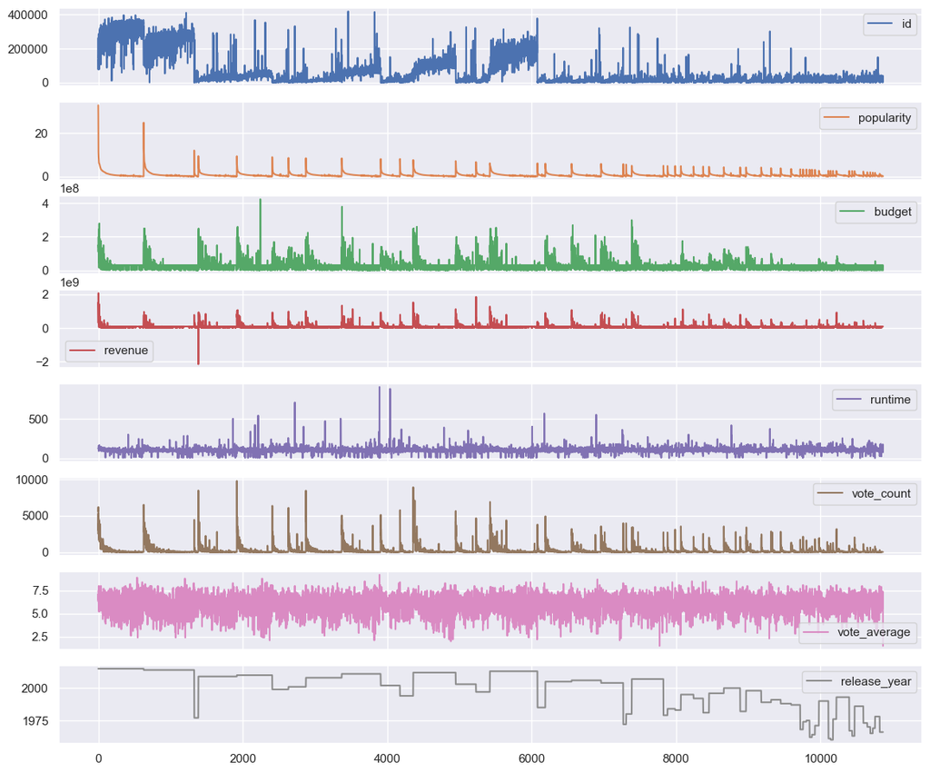

```python
data.plot(subplots=True,figsize=(14,12)) #here we visualize data with lineplots
```

```
array([[<AxesSubplot:>, <AxesSubplot:>, <AxesSubplot:>],
       [<AxesSubplot:>, <AxesSubplot:>, <AxesSubplot:>],
       [<AxesSubplot:>, <AxesSubplot:>, <AxesSubplot:>],
       [<AxesSubplot:>, <AxesSubplot:>, <AxesSubplot:>],
       [<AxesSubplot:>, <AxesSubplot:>, <AxesSubplot:>],
       [<AxesSubplot:>, <AxesSubplot:>, <AxesSubplot:>],
       [<AxesSubplot:>, <AxesSubplot:>, <AxesSubplot:>],
       [<AxesSubplot:>, <AxesSubplot:>, <AxesSubplot:>]], dtype=object)
```

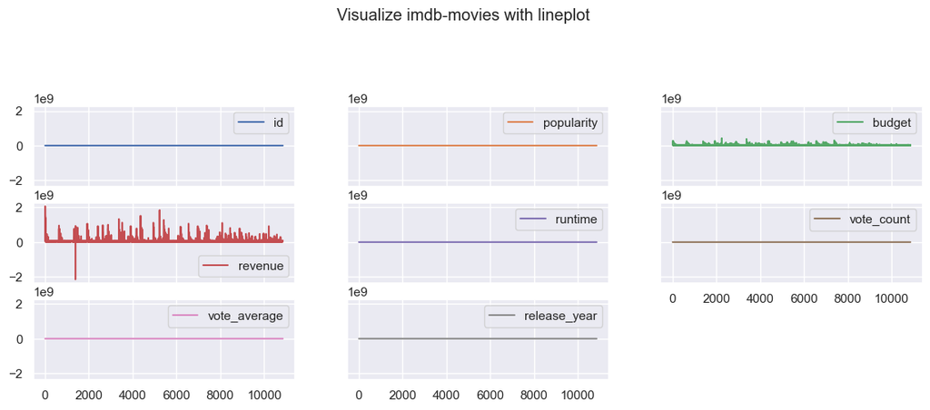

```python
data.plot(subplots=True,layout=(8,3),figsize=(14,12),legend=True,title='Visualize imdb-movies with lineplot',sharey=True)
```

## relationship between variables of dataset with scatterplot and densityplot

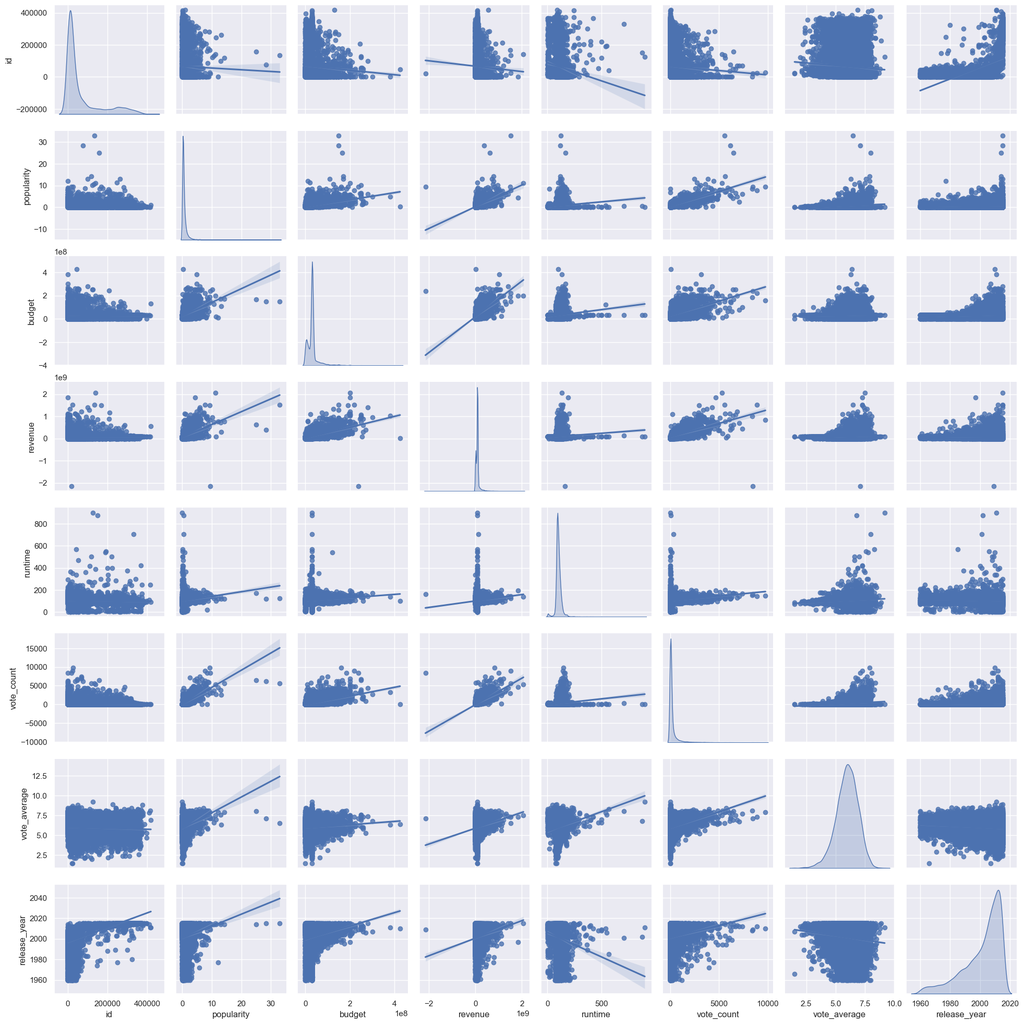

```python
#here we visualize data with scatterplot and densityplot
sns.pairplot(data, kind="reg", diag_kind="kde", diag_kws=dict(shade=True))
```

### we noticed:

- relationship between runtime and id decreases
- relationship between runtime and release year decreases
- relationship between vote count and popularity increases
- relationship between vote count and budget increases
- relationship between vote count and revenue increases
- relationship between popularity and vote count increases
- relationship between popularity and vote average increases
- relationship between runtime and vote_average increases
- relationship between popularity and release_year increases
- relationship between popularity and id slightly decreases

### Research Question 1 (what is the highest rated movie over all years?)

```python
#we group original title with vote rating
top_movies=data.groupby('original_title').mean()['vote_average']
top_movies #show result
```

```
original_title
$5 a Day                              5.4
$9.99                                 6.1
'71                                   6.6
(500) Days of Summer                  7.3
(T)Raumschiff Surprise - Periode 1    6.3
                                     ...
ì˜í˜•ì œ                              6.3
ì‹ ì˜ í•œ ìˆ˜                         6.8
í¬í™” ì†ìœ¼ë¡œ                        6.9
í˜•ì‚¬ Duelist                        5.2
í•˜ìš¸ë§                              5.8
Name: vote_average, Length: 10507, dtype: float64
```

> we group original title with vote rating

```python
sort_movies = top_movies.sort_values(ascending=False) #taking movies with highest vote ratings
sort_movies.head() #show movies with highest vote average
```

```
original_title
The Story of Film: An Odyssey    9.2
The Mask You Live In             8.9
Life Cycles                      8.8
Black Mirror: White Christmas    8.8
Pink Floyd: Pulse                8.7
Name: vote_average, dtype: float64
```

> taking movies with highest vote ratings

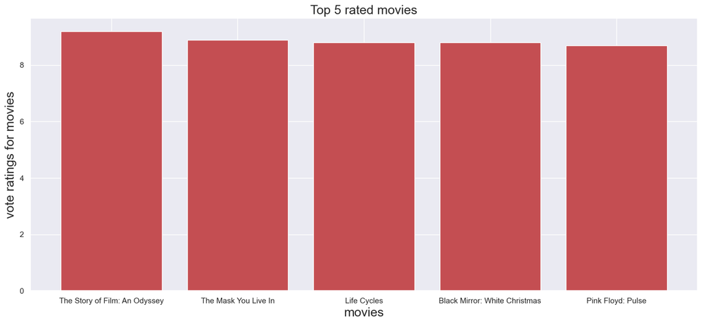

```python
#visualize movies with highest vote ratings
plt.subplots(figsize=(17,7),dpi=100)
plt.bar(sort_movies.index[:5],sort_movies[:5],color='r')
plt.title('Top 5 rated movies',fontsize=18)
plt.xlabel('movies',fontsize=18)
plt.ylabel('vote ratings for movies',fontsize=18);
```

## in other way the question can be asked (why the story of film: an odyssey has the highest rate)

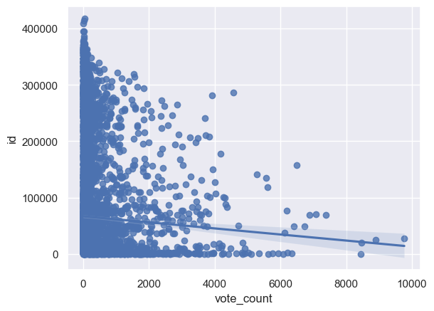

```python
sns.regplot(x='vote_count',y='id',data=data)
```

## we found:

- relationship between vote_count and id slightly decrease

### Research Question 2 (what is the top eight popular movies?)

```python
#we group original title with popularity
popular_movies=data.groupby('original_title').mean()['popularity']
popular_movies #show result
```

```
original_title
$5 a Day                              0.298961
$9.99                                 0.204302
'71                                   1.220073
(500) Days of Summer                  3.244139
(T)Raumschiff Surprise - Periode 1    0.712887
                                        ...
ì˜í˜•ì œ                              0.146543
ì‹ ì˜ í•œ ìˆ˜                         0.205343
í¬í™” ì†ìœ¼ë¡œ                        0.507092
í˜•ì‚¬ Duelist                        0.265905
í•˜ìš¸ë§                              0.142769
Name: popularity, Length: 10507, dtype: float64
```

> we group original title with popularity

```python
popularity = popular_movies.sort_values(ascending=False) #taking movies with highest popularity
popularity.head(8) #show first 8 of them
```

```
original_title
Jurassic World                         32.985763
Mad Max: Fury Road                     28.419936
Interstellar                           24.949134
Guardians of the Galaxy                14.311205
Insurgent                              13.112507
Captain America: The Winter Soldier    12.971027
Star Wars                              12.037933
John Wick                              11.422751
Name: popularity, dtype: float64
```

> taking movies with highest popularity

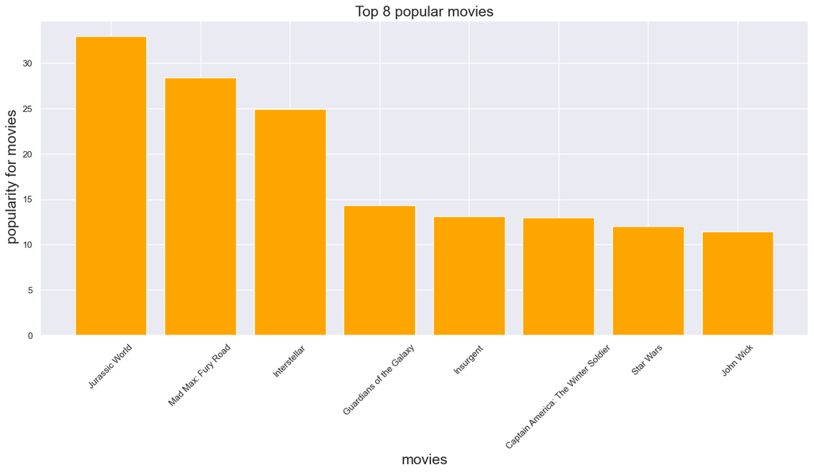

```python
#visualize movies with  popularity
fig, ax=plt.subplots(figsize=(17,7))
plt.bar(popularity[:8].index,popularity[:8],color='orange')
ax.tick_params(axis='x',rotation=45)
plt.title('Top 8 popular movies',fontsize=18)
plt.xlabel('movies',fontsize=18)
plt.ylabel(' popularity for movies',fontsize=18);
```

### conclusion of visualize movies with popularity:

- jurassic world is the most popular movie
- mad max: fury road is the second most popular movie
- interstellar is the third most popular movie
- guardians of the galaxy is the forth most popular movie
- insturgent is the fifth most popular movie
- captain america: the winter solider is the sixth most popular movie
- star wars is the seventh most popular movie
- john wick is the eighth most popular movie

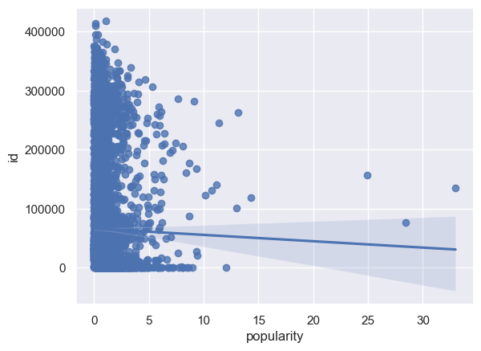

```python
sns.regplot(x='popularity',y='id',data=data)
```

## There is slightly decrease between popularity and id features also they are nearly constant

### Research Question 3 (which director have produced the best movies in 2010?)

```python
year=data[data['release_year'] == 2010] #taking data where release year is 2010
```

> taking data where release year is 2010

```python
director = year.groupby('director').mean().vote_average #group director with vote average in year 2010
```

> group director with vote average in year 2010

```python
dir_high = director.sort_values(ascending=False) #taking the highest directors with vote average in year 2010
dir_high.head(6) #show first 6 data
```

```
director
Derek Frankowski          8.8
Sam Dunn|Scot McFadyen    8.4
Dean Wellins              8.3
Richard Press             8.1
Asif Kapadia              8.0
Louis C.K.                7.9
Name: vote_average, dtype: float64
```

> taking the highest directors with vote average in year 2010

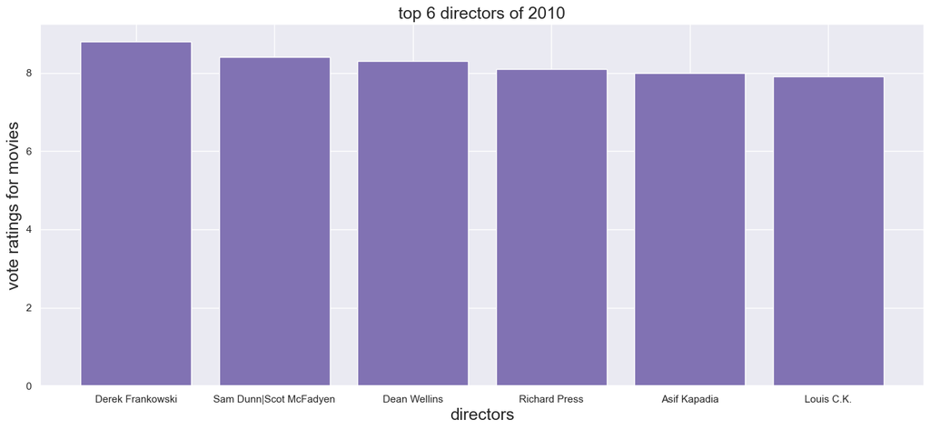

```python
#visualization of first 6 directors with highest vote average in 2010
fig, ax=plt.subplots(figsize=(17,7))
plt.bar(dir_high.index[:6],dir_high[:6],color='m')
ax.tick_params(axis='x')
plt.title('top 6 directors of 2010',fontsize=18)
plt.xlabel('directors',fontsize=18)
plt.ylabel('vote ratings for movies',fontsize=18);
```

### Research Question 4 (what is the average vote_count for movies?)

```python
def avg_fun(column):
    return data[column].mean()
```

```python
avg_fun('vote_count') #the average of vote count
```

```
218.60074074074075
```

> the average vote count for movies is 218.60074074074075

```python
data.describe() #describing our data
```

|  | id | popularity | budget | revenue | runtime | vote_count | vote_average | release_year |
| --- | --- | --- | --- | --- | --- | --- | --- | --- |
| count | 10800.000000 | 10800.000000 | 1.080000e+04 | 1.080000e+04 | 10800.000000 | 10800.000000 | 10800.000000 | 10800.000000 |
| mean | 65576.183426 | 0.649455 | 3.076690e+07 | 8.879861e+07 | 102.454167 | 218.600741 | 5.970880 | 2001.289537 |
| std | 91756.079939 | 1.002441 | 2.690649e+07 | 1.076323e+08 | 30.339755 | 577.165055 | 0.933006 | 12.819545 |
| min | 5.000000 | 0.000188 | 1.000000e+00 | -2.147484e+09 | 2.000000 | 10.000000 | 1.500000 | 1960.000000 |
| 25% | 10570.500000 | 0.209156 | 1.900000e+07 | 4.048170e+07 | 90.000000 | 17.000000 | 5.400000 | 1995.000000 |
| 50% | 20460.000000 | 0.385471 | 3.076690e+07 | 8.925500e+07 | 99.000000 | 39.000000 | 6.000000 | 2006.000000 |
| 75% | 74725.250000 | 0.717508 | 3.076690e+07 | 8.925500e+07 | 111.250000 | 147.000000 | 6.600000 | 2011.000000 |
| max | 417859.000000 | 32.985763 | 4.250000e+08 | 2.068178e+09 | 900.000000 | 9767.000000 | 9.200000 | 2015.000000 |

> we show descriptive statistic of our data

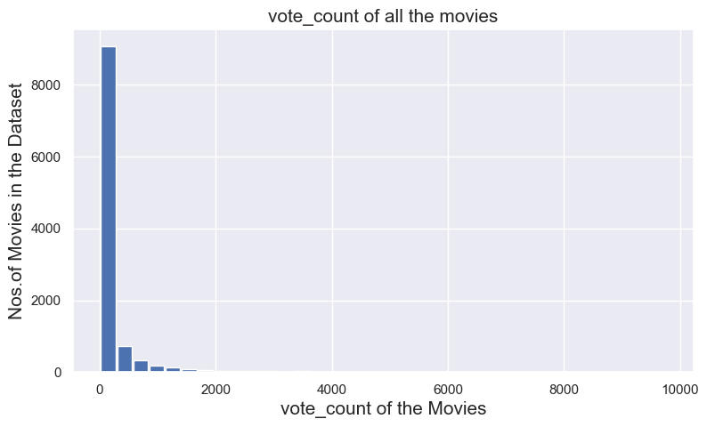

```python
#visualize vote count for all movies
plt.figure(figsize=(9,5), dpi = 100)
plt.xlabel('vote_count of the Movies', fontsize = 15)
plt.ylabel('Nos.of Movies in the Dataset', fontsize=15)
plt.title('vote_count of all the movies', fontsize=15)
plt.hist(data['vote_count'],rwidth = 0.9, bins =35)
```

### conclusion of visualize vote count for all movies

- we conclude that vote count is right skewed

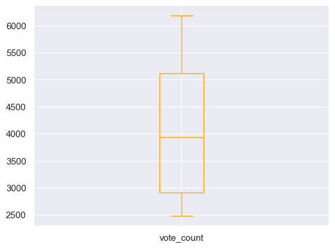

```python
data1=data.iloc[0:10]
data1.plot(kind='box',y='vote_count',color='orange')
```

### Research Question 5 (which movies have the highest runtime?)

```python
low_runtime=data.groupby('original_title').mean()['runtime'] #group original title with runtime
low_runtime #show data
```

```
original_title
$5 a Day                               98.0
$9.99                                  78.0
'71                                    99.0
(500) Days of Summer                   95.0
(T)Raumschiff Surprise - Periode 1     87.0
                                      ...
ì˜í˜•ì œ                              116.0
ì‹ ì˜ í•œ ìˆ˜                         118.0
í¬í™” ì†ìœ¼ë¡œ                        120.0
í˜•ì‚¬ Duelist                        111.0
í•˜ìš¸ë§                              114.0
Name: runtime, Length: 10507, dtype: float64
```

> group original title with runtime

```python
low_runtime = low_runtime.sort_values(ascending=False) #take the movies with highest runtime
low_runtime.head() #showing first five data
```

```
original_title
The Story of Film: An Odyssey    900.0
Band of Brothers                 705.0
Shoah                            566.0
Planet Earth                     550.0
The Pacific                      540.0
Name: runtime, dtype: float64
```

> take the movies with highest runtime

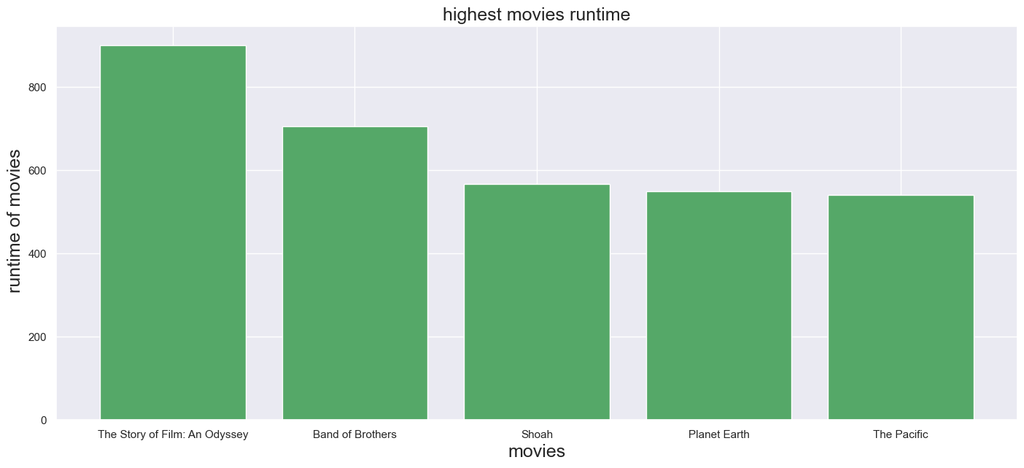

```python
#visualization of movies with runtime of movies
fig, ax=plt.subplots(figsize=(17,7))
plt.bar(low_runtime.index[:5],low_runtime[:5],color='g')
plt.title('highest movies runtime',fontsize=18)
plt.xlabel('movies',fontsize=18)
plt.ylabel(' runtime of movies',fontsize=18);
```

### conclusion of visualization of movies with runtime of movies

- the story of film: an odyssey has the highest movies runtime
- band of brothers has the second highest movies runtime
- shoah has the third highest movies runtime
- planet earth has the forth highest movies runtime
- the pacific has the fifth highest movies runtime

### in other way the question can be asked why the story of film: an odyssey have the highest runtime?

### Research Question 6 (what is the relationship between revenue and popularity)

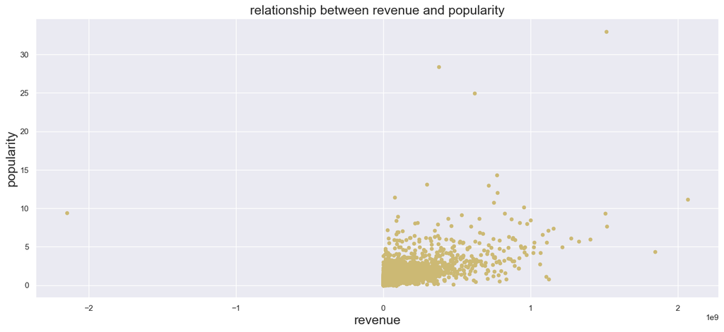

```python
#scatterplot between revenue and popularity
data.plot(x='revenue',y='popularity',kind='scatter',color='y',figsize=(17,7))
plt.title('relationship between revenue and popularity',fontsize=18)
plt.xlabel('revenue',fontsize=18)
plt.ylabel('popularity',fontsize=18);
```

### conclusion:

- the relationship between between revenue and popularity increases

### Research Question 7 (what is the relationship between revenue and budget)

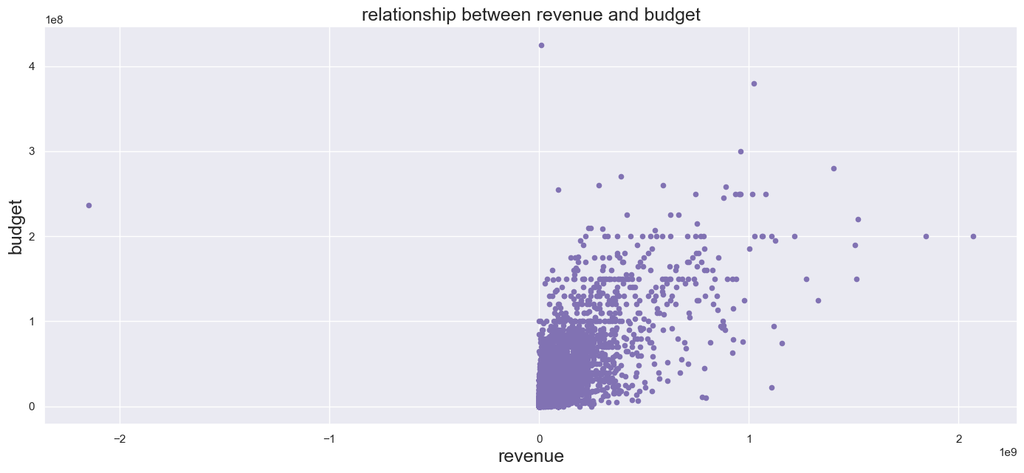

```python
#scatterplot between revenue and budget
data.plot(x='revenue',y='budget',kind='scatter',color='m',figsize=(17,7))
plt.title('relationship between revenue and budget',fontsize=18)
plt.xlabel('revenue',fontsize=18)
plt.ylabel('budget',fontsize=18);
```

### conclusion:

- the relationship between revenue and budget increases

### Research Question 8 (what is the relationship between budget and popularity)

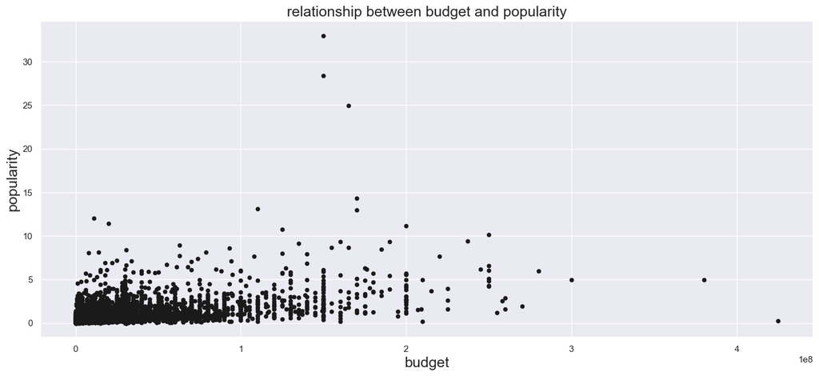

```python
#scatterplot between budget and popularity
data.plot(x='budget',y='popularity',kind='scatter',color='k',figsize=(17,7))
plt.title('relationship between budget and popularity',fontsize=18)
plt.xlabel('budget',fontsize=18)
plt.ylabel('popularity',fontsize=18);
```

### conclusion:

- the relationship between budget and popularity increases

### Research Question 9 (Which Movie Has The Highest profit? or Why Avatar Movie Have The Highest Profit?)

```python
data['profit'] = data['revenue']-data['budget'] #calculating profit
data['profit'] #show data of profit
```

```
0        1363528810
1         228436354
2         185238201
3        1868178225
4        1316249360
            ...
10861      58488095
10862      58488095
10863      58488095
10864      58488095
10865      89235997
Name: profit, Length: 10800, dtype: int32
```

> calculating profit

```python
group_profit=data.groupby('original_title').mean()['profit'] #group original title with profit
group_profit
```

```
original_title
$5 a Day                              58488095.0
$9.99                                 58488095.0
'71                                  -29141055.0
(500) Days of Summer                  53222734.0
(T)Raumschiff Surprise - Periode 1    58488095.0
                                         ...
ì˜í˜•ì œ                              58488095.0
ì‹ ì˜ í•œ ìˆ˜                         58488095.0
í¬í™” ì†ìœ¼ë¡œ                        89244997.0
í˜•ì‚¬ Duelist                        58488095.0
í•˜ìš¸ë§                              58488095.0
Name: profit, Length: 10507, dtype: float64
```

> group original title with profit

```python
high_profit = group_profit.sort_values(ascending=False) #taking the movies with highest profit
high_profit.head()
```

```
original_title
Avatar                                          1.910484e+09
Star Wars: The Force Awakens                    1.868178e+09
Jurassic World                                  1.363529e+09
Furious 7                                       1.316249e+09
Harry Potter and the Deathly Hallows: Part 2    1.202818e+09
Name: profit, dtype: float64
```

> taking the movies with highest profit

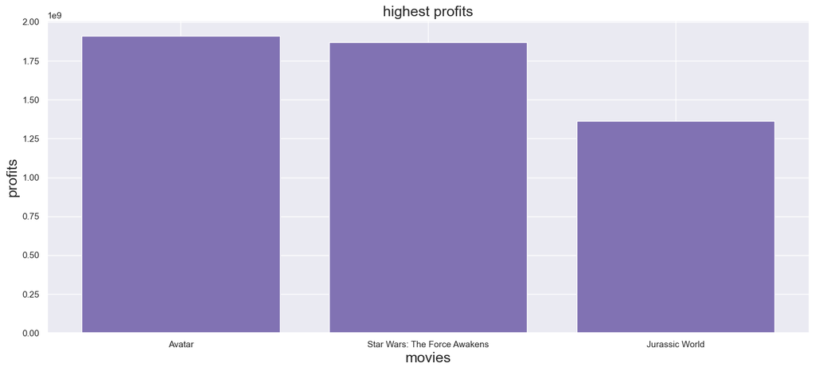

```python
#visualization between movies and profit
fig, ax=plt.subplots(figsize=(17,7))
plt.bar(high_profit.index[:3],high_profit[:3],color='m')
ax.tick_params(axis='x')
plt.title('highest profits',fontsize=18)
plt.xlabel('movies',fontsize=18)
plt.ylabel('profits',fontsize=18);
```

### conclusion of visualization between movies and profit

- avatar movie have the highest profit
- star wars:the force awakens have the second highest profit
- jurassic world have the third highest profit

### Research Question 10 : How Many Movies with most and least earned revenue

```python
import pprint
#defining the function
def calculate(column):
    top= data[column].idxmax()
    top_info=pd.DataFrame(data.loc[top])

    low= data[column].idxmin()
    low_info=pd.DataFrame(data.loc[low])

    #collectin data in one place
    collect=pd.concat([top_info, low_info], axis=1)

    return collect
```

> defining the function, for highest earned revenue, lowest earned revenue and collect data in one place

```python
calculate('revenue')
```

|  | 3 | 1386 |
| --- | --- | --- |
| id | 140607 | 19995 |
| popularity | 11.173104 | 9.432768 |
| budget | 200000000 | 237000000 |
| revenue | 2068178225 | -2147483648 |
| original_title | Star Wars: The Force Awakens | Avatar |
| director | J.J. Abrams | James Cameron |
| runtime | 136 | 162 |
| genres | Action\|Adventure\|Science Fiction\|Fantasy | Action\|Adventure\|Fantasy\|Science Fiction |
| release_date | 12/15/15 | 12/10/09 |
| vote_count | 5292 | 8458 |
| vote_average | 7.5 | 7.1 |
| release_year | 2015 | 2009 |
| profit | 1868178225 | 1910483648 |

## Limitations

- id, imdb_id columns are similar column so we can get rid of one of them. I dropped imdb_id column which is not given any useful information for this analysis. also it's a string
- i dropped budget_adj,revenue_adj columns as i will use budget and revenue columns instead
- we replaced zero values with mean instead of dropping them because they are too many
- data type of budget, revenue and runtime changed from int to float when replacing 0 to NaN in these columns

```python
##from subprocess import call
##call(['python', '-m', 'nbconvert', 'Investigate_a_Dataset.ipynb'])
```